# Recpature distances

Rosie

2023-03-16

## Spatial stats on Delta Smelt releases

We have four different release types and a few questions we can ask.

1. How far did smelt from each release group travel before being recaptured?
2. How variable was the distance between release and recapture?
3. How close together were fish from a particular release when they were recaptured?
4. How variable was the distance between fish on recapture?

Sam Bashevkin has written some nifty functions for calculating in=water distance between points (fish) and a reference point (release location) or between a group of points (fish from a particular release).

https://github.com/sbashevkin/spacetools

Fist let’s calcualte distance from release location to recapture location.

```r
#Bring in the data and check it out


recaps = read_excel("Recaptured Experimental Release_2022-2023_working draft (2).xlsx",
                    sheet = "Full DSM Data") %>%
  rename(Site = `Release Site`, Type = `Release Type`, Latitude= `Start Latitude`, Longitude = `Start Longitude`,
         Mark = `VIE Color/Position`)
recaps    =     mutate(recaps, fishID = paste("smelt", 1:nrow(recaps)),
                Type = case_when(Type == "header" ~ "Soft",
                                 is.na(Type) ~ "Wild",
                                 TRUE ~ Type),
                Site = case_when(is.na(Site) ~ "Wild",
                                 TRUE ~ Site))
str(recaps)
```

```
## tibble [46 × 16] (S3: tbl_df/tbl/data.frame)
##  $ Date        : POSIXct[1:46], format: "2022-12-14" "2022-12-14" ...
##  $ Survey      : chr [1:46] "FCCL" "FCCL" "TFCF" "EDSM" ...
##  $ Gear Type   : chr [1:46] "Lampara" "Lampara" "Salvage" "Kodiak" ...
##  $ Region      : chr [1:46] "Lower Sacramento" "Lower Sacramento" "South Delta" "Southern Delta" ...
##  $ Sub Region  : chr [1:46] "Lower Sacramento" "Lower Sacramento" "South Delta" "Franks Tract" ...
##  $ Station Code: chr [1:46] NA NA NA "23-25-SD02" ...
##  $ Latitude    : num [1:46] NA NA 37.8 38 38 ...
##  $ Longitude   : num [1:46] NA NA -122 -122 -122 ...
##  $ Forklength  : chr [1:46] "NA" NA "74" "71" ...
##  $ Marked      : chr [1:46] "Yes" "No" "Yes" "No" ...
##  $ Ad clip     : chr [1:46] "No" NA "No" NA ...
##  $ Mark        : chr [1:46] "Left/Red/AD" NA "Left/Red/AD" NA ...
##  $ Type        : chr [1:46] "Hard" "Wild" "Hard" "Wild" ...
##  $ Site        : chr [1:46] "Rio Vista" "Wild" "Rio Vista" "Wild" ...
##  $ Release Date: POSIXct[1:46], format: "2022-11-30" NA ...
##  $ fishID      : chr [1:46] "smelt 1" "smelt 2" "smelt 3" "smelt 4" ...
```

This just needs a little data manipulation

```r
#Now make a data frame of the release locations
release = read_excel("releases.xlsx") %>%
  rename(LatitudeR = Latitude, LongitudeR = Longitude)
releasesf = st_as_sf(filter(release, !is.na(LatitudeR)),  coords = c("LongitudeR", "LatitudeR"), crs = 4326)

#merge recap points with release points

recaps2 = left_join(recaps, release) %>%
  mutate(DaysSinceRelease = Date - ReleaseDate)
```

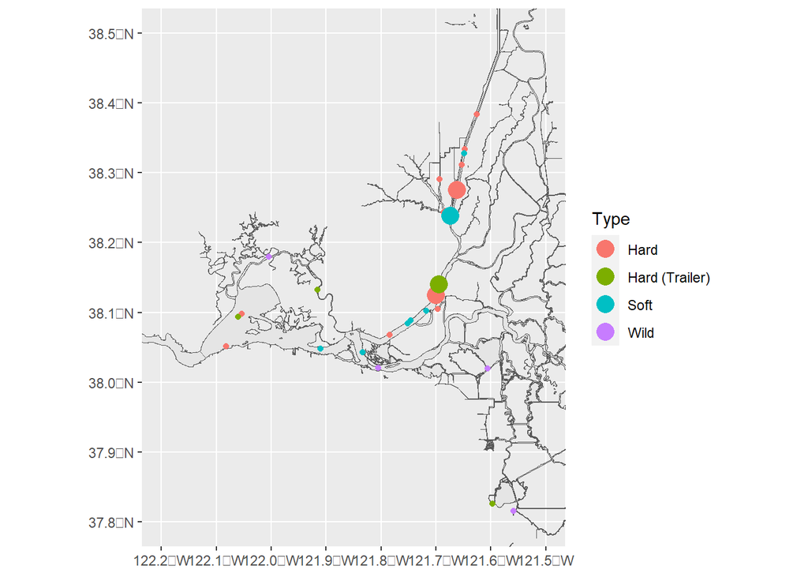

```r
recapsf = st_as_sf(filter(recaps2, !is.na(`Longitude`)), coords = c("Longitude", "Latitude"), crs = 4326)

#make a quick plot to make sure I did it right
ggplot()+
  geom_sf(data = WW_Delta)+
  geom_sf(data = recapsf, aes(color = Type))+
  geom_sf(data = releasesf, aes(color = Type), size = 5)+

  coord_sf(xlim = c(-121.5, -122.2), ylim = c(37.8, 38.5))
```

Now we can calculate the distance between each point and the release location. I’m going to do it one release at a time. THere is probalby a way to vectorize this and do it all at once, but I’m too lazy to figure it out.

```r
#one release at a time
Dwschard = filter(recaps2, Type == "Hard", Site == "SDWSC")
dwsch = filter(release, Site == "SDWSC", Type == "Hard") %>%
  select(LatitudeR, LongitudeR) %>%
  rename(Latitude = LatitudeR, Longitude = LongitudeR)
tesst = GGdist(Water_map = spacetools::Delta, Points = Dwschard, Latitude_column = `Latitude`,
               Longitude_column = `Longitude`, PointID_column = fishID, EndPoint = dwsch)

#now let's do DWSC soft
Dwscsoft = filter(recaps2, Type == "Soft", Site == "SDWSC")
dwscs = filter(release, Site == "SDWSC", Type == "Soft") %>%
  select(LatitudeR, LongitudeR)%>%
  rename(Latitude = LatitudeR, Longitude = LongitudeR)
tesst2 = GGdist(Water_map = spacetools::Delta, Points = Dwscsoft, Latitude_column = `Latitude`,
               Longitude_column = `Longitude`, PointID_column = fishID, EndPoint = dwscs)

#now let's do Rio Vista hard
RVhard = filter(recaps2, Type == "Hard", Site == "Rio Vista", !is.na(Latitude))
rvh = filter(release, Site == "Rio Vista", Type == "Hard") %>%
  select(LatitudeR, LongitudeR)%>%
  rename(Latitude = LatitudeR, Longitude = LongitudeR) %>%
  distinct()
tesst3 = GGdist(Water_map = spacetools::Delta, Points = RVhard, Latitude_column = `Latitude`,
                Longitude_column = `Longitude`, PointID_column = fishID, EndPoint = rvh)

#now the trailer
RVhardt = filter(recaps2, Type == "Hard (Trailer)", Site == "Rio Vista")
rvht = filter(release, Site == "Rio Vista", Type == "Hard (Trailer)") %>%
  select(LatitudeR, LongitudeR)%>%
  rename(Latitude = LatitudeR, Longitude = LongitudeR)
tesst4 = GGdist(Water_map = spacetools::Delta, Points = RVhardt, Latitude_column = `Latitude`,
                Longitude_column = `Longitude`, PointID_column = fishID, EndPoint = rvht)

distances = bind_rows(tesst, tesst2, tesst3, tesst4)
```

OK, now let’s bind all the distances together and join them back to the origional dataset

```r
recaps3 = left_join(recaps2, distances) %>%
  mutate(SiteType = paste(Type, Site))
recaps3
```

```
## # A tibble: 46 × 25
##    Date                Survey `Gear Type` Region Sub R…¹ Stati…² Latit…³ Longi…⁴
##    <dttm>              <chr>  <chr>       <chr>  <chr>   <chr>     <dbl>   <dbl>
##  1 2022-12-14 00:00:00 FCCL   Lampara     Lower… Lower … <NA>       NA       NA
##  2 2022-12-14 00:00:00 FCCL   Lampara     Lower… Lower … <NA>       NA       NA
##  3 2023-01-07 00:00:00 TFCF   Salvage     South… South … <NA>       37.8   -122.
##  4 2023-01-17 00:00:00 EDSM   Kodiak      South… Franks… 23-25-…    38.0   -122.
##  5 2023-01-19 00:00:00 Chipps mid-water   Suisu… Conflu… SB018N     38.0   -122.
##  6 2023-01-24 00:00:00 EDSM   Kodiak      Suisu… Mid-Su… 23-26-…    38.1   -122.
##  7 2023-01-26 00:00:00 EDSM   Kodiak      Cache… Cache … 23-26-…    38.2   -122.
##  8 2023-01-27 00:00:00 EDSM   Kodiak      Lower… Sacram… 23-26-…    38.1   -122.
##  9 2023-01-30 00:00:00 EDSM   Kodiak      Suisu… Mid-Su… 23-27-…    38.1   -122.
## 10 2023-01-30 00:00:00 EDSM   Kodiak      Lower… Lower … 23-27-…    38.1   -122.
## # … with 36 more rows, 17 more variables: Forklength <chr>, Marked <chr>,
## #   `Ad clip` <chr>, Mark <chr>, Type <chr>, Site <chr>, `Release Date` <dttm>,
## #   fishID <chr>, ReleaseEvent <chr>, ReleaseDate <dttm>, Adclip <chr>,
## #   TotalReleased <dbl>, LatitudeR <dbl>, LongitudeR <dbl>,
## #   DaysSinceRelease <drtn>, Distance <dbl>, SiteType <chr>, and abbreviated
## #   variable names ¹`Sub Region`, ²`Station Code`, ³Latitude, ⁴Longitude
```

Plot to visually look at mean and variation.

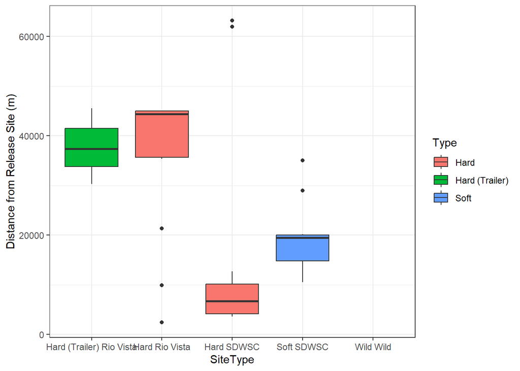

```r
ggplot(recaps3, aes(x = SiteType, y = Distance))+ geom_boxplot(aes(fill = Type))+
  ylab("Distance from Release Site (m)")+
  theme_bw()
```

Map with color variation by distance, to make sure I got it right.

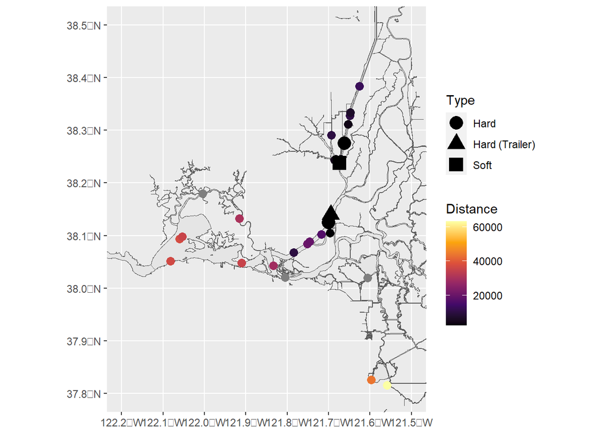

```r
recapsf = st_as_sf(filter(recaps3, !is.na(`Longitude`)), coords = c("Longitude", "Latitude"), crs = 4326)


ggplot()+
  geom_sf(data = WW_Delta)+
  geom_sf(data = recapsf, aes(color = Distance), size =3)+
  geom_sf(data = releasesf, aes(shape = Type), size = 5)+
  scale_color_viridis_c(option = "B")+
  coord_sf(xlim = c(-121.5, -122.2), ylim = c(37.8, 38.5))
```

```r
recapsum = group_by(recaps3, Site, Type, SiteType) %>%
  summarize(Nsmelt = n(), MeanDist = mean(Distance, na.rm = T), sdDist = sd(Distance, na.rm =T))
recapsum
```

```
## # A tibble: 5 × 6
## # Groups:   Site, Type [5]
##   Site      Type           SiteType                 Nsmelt MeanDist sdDist
##   <chr>     <chr>          <chr>                     <int>    <dbl>  <dbl>
## 1 Rio Vista Hard           Hard Rio Vista               15   36297. 14439.
## 2 Rio Vista Hard (Trailer) Hard (Trailer) Rio Vista      3   37723.  7643.
## 3 SDWSC     Hard           Hard SDWSC                   13   14840. 21352.
## 4 SDWSC     Soft           Soft SDWSC                   10   19710.  7370.
## 5 Wild      Wild           Wild Wild                     5     NaN     NA
```

```r
#ANOVA of differences in distance by release group
library(emmeans)
m1 = lm(Distance ~ SiteType, data = recaps3)
summary(m1)
```

```
##
## Call:
## lm(formula = Distance ~ SiteType, data = recaps3)
##
## Residuals:
##    Min     1Q Median     3Q    Max
## -33888  -8389   -648   8692  48343
##
## Coefficients:
##                        Estimate Std. Error t value Pr(>|t|)
## (Intercept)               37723       9020   4.182 0.000177 ***
## SiteTypeHard Rio Vista    -1426       9940  -0.143 0.886738
## SiteTypeHard SDWSC       -22883      10007  -2.287 0.028197 *
## SiteTypeSoft SDWSC       -18013      10284  -1.752 0.088371 .
## ---
## Signif. codes:  0 '***' 0.001 '**' 0.01 '*' 0.05 '.' 0.1 ' ' 1
##
## Residual standard error: 15620 on 36 degrees of freedom
##   (6 observations deleted due to missingness)
## Multiple R-squared:  0.3069, Adjusted R-squared:  0.2492
## F-statistic: 5.314 on 3 and 36 DF,  p-value: 0.003896
```

```r
anova(m1)
```

```
## Analysis of Variance Table
##
## Response: Distance
##           Df     Sum Sq    Mean Sq F value   Pr(>F)
## SiteType   3 3890925453 1296975151  5.3138 0.003896 **
## Residuals 36 8786810511  244078070
## ---
## Signif. codes:  0 '***' 0.001 '**' 0.01 '*' 0.05 '.' 0.1 ' ' 1
```

```r
emmeans(m1, pairwise ~ SiteType)
```

```
## $emmeans
##  SiteType                 emmean   SE df lower.CL upper.CL
##  Hard (Trailer) Rio Vista  37723 9020 36    19430    56016
##  Hard Rio Vista            36297 4175 36    27829    44766
##  Hard SDWSC                14840 4333 36     6053    23628
##  Soft SDWSC                19710 4940 36     9690    29730
##
## Confidence level used: 0.95
##
## $contrasts
##  contrast                                  estimate    SE df t.ratio p.value
##  Hard (Trailer) Rio Vista - Hard Rio Vista     1426  9939 36   0.143  0.9989
##  Hard (Trailer) Rio Vista - Hard SDWSC        22883 10007 36   2.287  0.1201
##  Hard (Trailer) Rio Vista - Soft SDWSC        18013 10284 36   1.752  0.3130
##  Hard Rio Vista - Hard SDWSC                  21457  6017 36   3.566  0.0055
##  Hard Rio Vista - Soft SDWSC                  16588  6469 36   2.564  0.0668
##  Hard SDWSC - Soft SDWSC                      -4869  6571 36  -0.741  0.8799
##
## P value adjustment: tukey method for comparing a family of 4 estimates
```

```
## I bet you wanted to call this with just object[[1]] - use '[[]]' or which' if I'm wrong.
## See '? emm_list' for more information
```

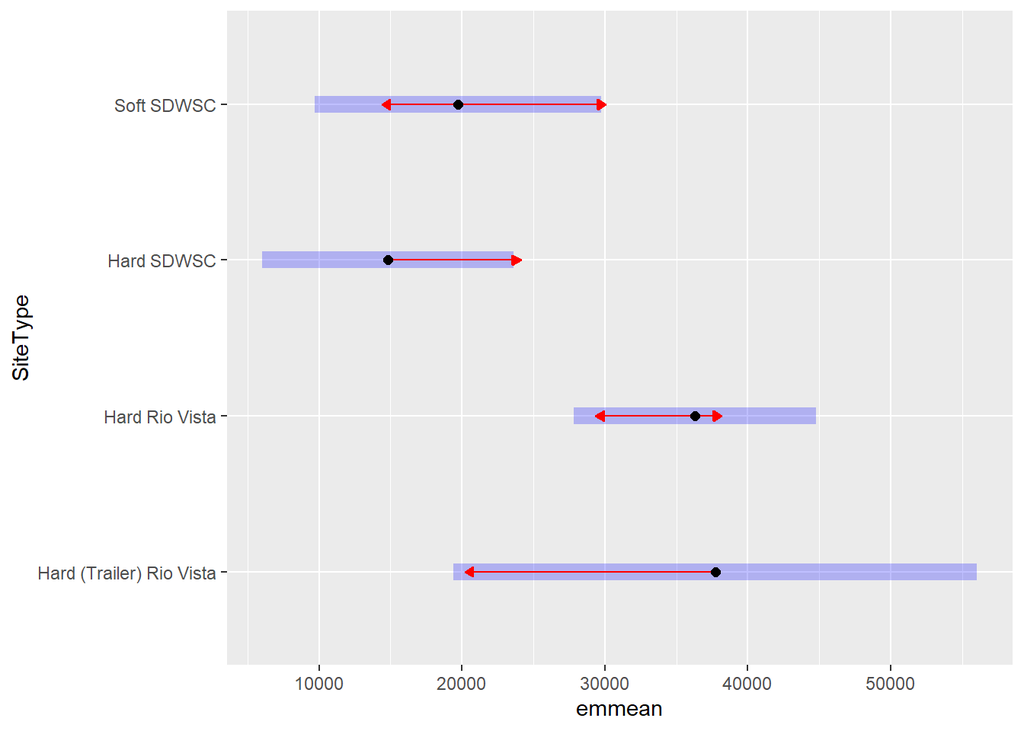

```r
plot(emmeans(m1, pairwise ~ SiteType), comparisons = T)
```

```r
#so hard releases at RIo Vista traveled further from hard releases at SDWSC, but no other significant differences
```

```r
#ANOVA of differences in distance by release event
m1.1 = lm(Distance ~ ReleaseEvent, data = recaps3)
summary(m1.1)
```

```
##
## Call:
## lm(formula = Distance ~ ReleaseEvent, data = recaps3)
##
## Residuals:
##    Min     1Q Median     3Q    Max
## -33244  -8389  -1242   8399  48343
##
## Coefficients:
##                Estimate Std. Error t value Pr(>|t|)
## (Intercept)       40162      11182   3.592 0.000998 ***
## ReleaseEvent2a    -4509      12078  -0.373 0.711155
## ReleaseEvent2b    -2439      14435  -0.169 0.866802
## ReleaseEvent3a   -25322      12011  -2.108 0.042242 *
## ReleaseEvent3b   -20452      12249  -1.670 0.103893
## ---
## Signif. codes:  0 '***' 0.001 '**' 0.01 '*' 0.05 '.' 0.1 ' ' 1
##
## Residual standard error: 15810 on 35 degrees of freedom
##   (6 observations deleted due to missingness)
## Multiple R-squared:  0.3097, Adjusted R-squared:  0.2308
## F-statistic: 3.925 on 4 and 35 DF,  p-value: 0.009797
```

```r
anova(m1.1)
```

```
## Analysis of Variance Table
##
## Response: Distance
##              Df     Sum Sq   Mean Sq F value   Pr(>F)
## ReleaseEvent  4 3925776909 981444227  3.9249 0.009797 **
## Residuals    35 8751959056 250055973
## ---
## Signif. codes:  0 '***' 0.001 '**' 0.01 '*' 0.05 '.' 0.1 ' ' 1
```

```r
emmeans(m1.1, pairwise ~ ReleaseEvent)
```

```
## $emmeans
##  ReleaseEvent emmean    SE df lower.CL upper.CL
##  1b            40162 11182 35    17462    62862
##  2a            35653  4565 35    26386    44920
##  2b            37723  9130 35    19189    56258
##  3a            14840  4386 35     5937    23744
##  3b            19710  5001 35     9558    29862
##
## Confidence level used: 0.95
##
## $contrasts
##  contrast estimate    SE df t.ratio p.value
##  1b - 2a      4509 12077 35   0.373  0.9957
##  1b - 2b      2439 14435 35   0.169  0.9998
##  1b - 3a     25322 12011 35   2.108  0.2394
##  1b - 3b     20452 12249 35   1.670  0.4650
##  2a - 2b     -2070 10207 35  -0.203  0.9996
##  2a - 3a     20813  6330 35   3.288  0.0183
##  2a - 3b     15943  6771 35   2.355  0.1522
##  2b - 3a     22883 10129 35   2.259  0.1825
##  2b - 3b     18013 10409 35   1.730  0.4292
##  3a - 3b     -4869  6651 35  -0.732  0.9475
##
## P value adjustment: tukey method for comparing a family of 5 estimates
```

```
## I bet you wanted to call this with just object[[1]] - use '[[]]' or which' if I'm wrong.
## See '? emm_list' for more information
```

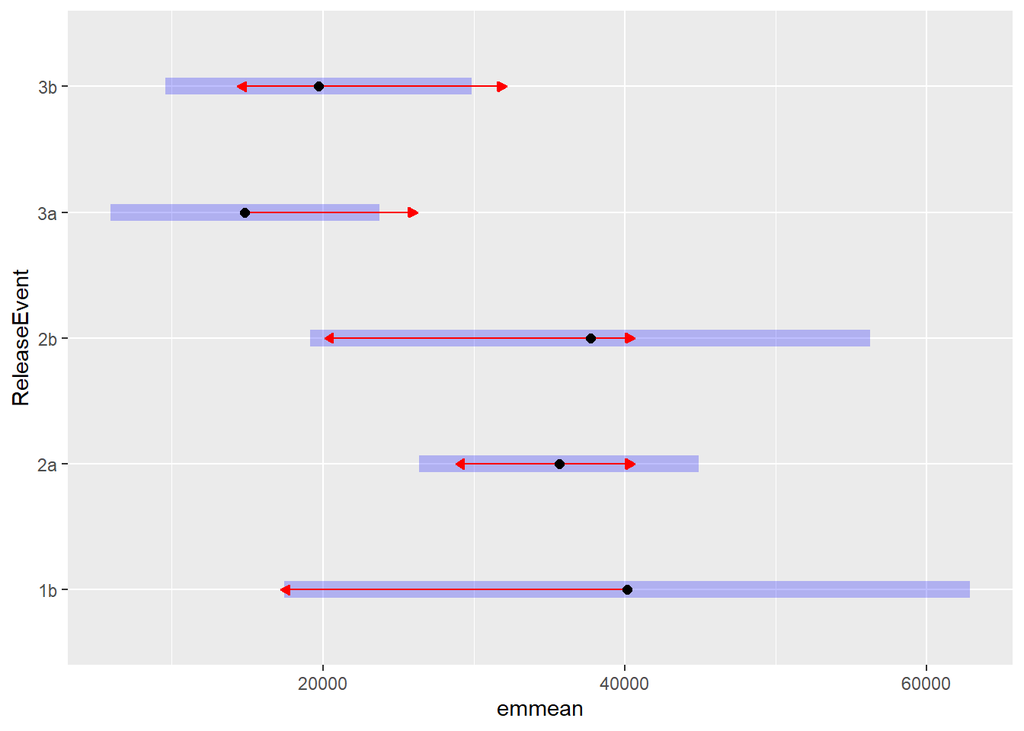

```r
plot(emmeans(m1.1, pairwise ~ ReleaseEvent), comparisons = T)
```

```r
#It's a bit of a mess.
```

Plot of distance to recapture over time by release type

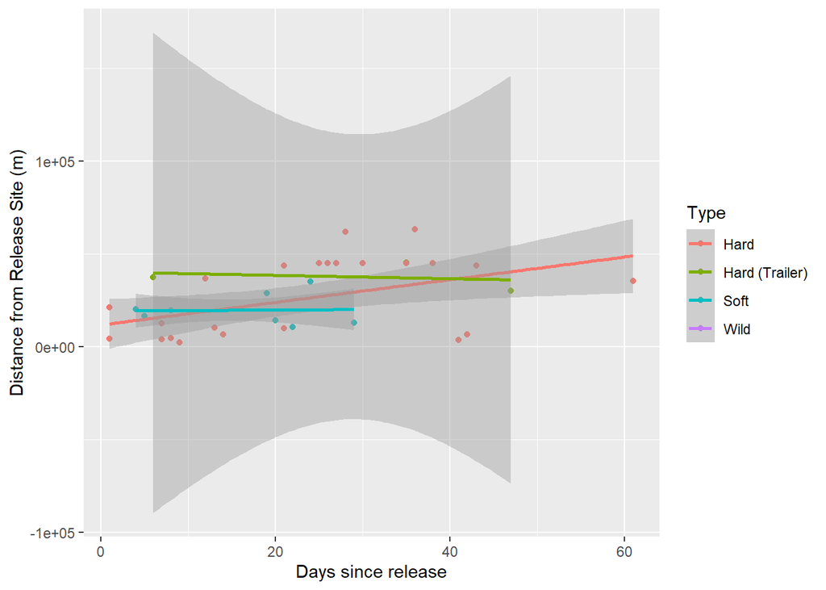

```r
ggplot(recaps3, aes(x = as.numeric(DaysSinceRelease), y = Distance, color = Type))+
  geom_point()+ geom_smooth(method = "lm")+ ylab("Distance from Release Site (m)")+
  xlab("Days since release")
```

Plot of distance to recapture over time by release site

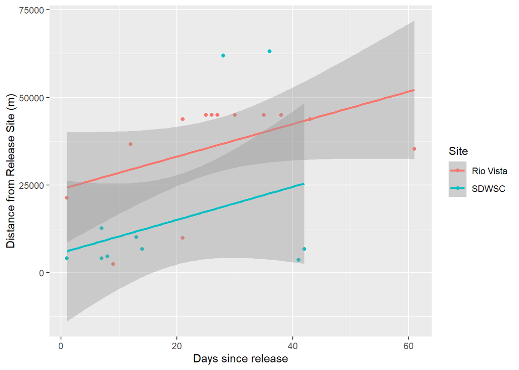

```r
ggplot(filter(recaps3, Type == "Hard"), aes(x = as.numeric(DaysSinceRelease), y = Distance, color = Site))+
  geom_point()+ geom_smooth(method = "lm")+ ylab("Distance from Release Site (m)")+
  xlab("Days since release")
```

NOw we move on to distance bewteen recaptured fish. I’m doing it oen release at a tiem again.

```r
RVhdist = Waterdist(Water_map = spacetools::Delta, Points = RVhardt, Latitude_column = `Latitude`,
                    Longitude_column = `Longitude`, PointID_column = fishID)

RVhdistx = Waterdist(Water_map = spacetools::Delta, Points = RVhard, Latitude_column = `Latitude`,
                    Longitude_column = `Longitude`, PointID_column = fishID)

SCsoft  = Waterdist(Water_map = spacetools::Delta, Points = Dwscsoft, Latitude_column = `Latitude`,
                       Longitude_column = `Longitude`, PointID_column = fishID)

SChard = Waterdist(Water_map = spacetools::Delta, Points = Dwschard, Latitude_column = `Latitude`,
                   Longitude_column = `Longitude`, PointID_column = fishID)

RVhdist
RVhdistx
SCsoft
SChard
```

[output not shown]

Let’s look at the mean of the lower triagle of each of these.

```r
Cluster = data.frame(Release = c("RV Hard", "RV Hard Trailer", "DWSC soft", "DWSC hard"),
                     meadist = c(mean(RVhdistx[lower.tri(RVhdistx)]),
                                 mean(RVhdist[lower.tri(RVhdist)]),
                                 mean(SCsoft[lower.tri(SCsoft)]),
                                 mean(SChard[lower.tri(SChard)])),
                     SD = c(sd(RVhdistx), sd(RVhdist), sd(SCsoft), sd(SChard)))

Cluster = mutate(Cluster, CV = SD/meadist)
Cluster
```

```
##           Release meadist SD CV
## 1         RV Hard      NA NA NA
## 2 RV Hard Trailer      NA NA NA
## 3       DWSC soft      NA NA NA
## 4       DWSC hard      NA NA NA
```

OK, now how to I put these all together to graph them?

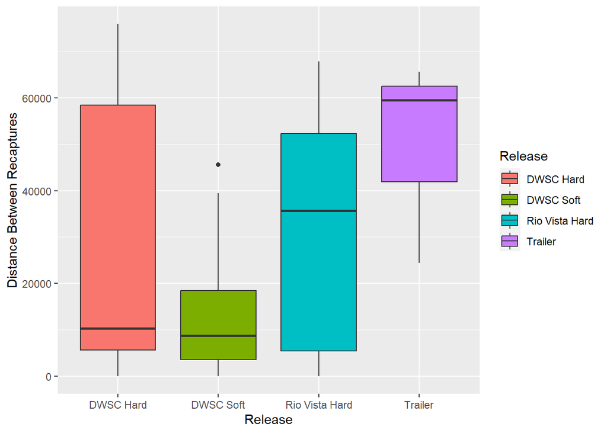

```r
RVhdistx[lower.tri(RVhdistx, diag = T)] = NA
RVhdist[lower.tri(RVhdist, diag = T)] = NA
SCsoft[lower.tri(SCsoft, diag = T)] = NA
SChard[lower.tri(SChard, diag = T)] = NA
RVdtx = as.data.frame(RVhdistx) %>%
  mutate(Fish1 = row.names(RVhdistx)) %>%
  pivot_longer(cols = -Fish1, names_to = "Fish2", values_to = "Distance") %>%
  filter(!is.na(Distance)) %>%
  mutate(Release = "Rio Vista Hard")

RVdt = as.data.frame(RVhdist) %>%
  mutate(Fish1 = row.names(RVhdist)) %>%
  pivot_longer(cols = -Fish1, names_to = "Fish2", values_to = "Distance") %>%
  filter(!is.na(Distance)) %>%
  mutate(Release = "Trailer")

SCs = as.data.frame(SCsoft) %>%
  mutate(Fish1 = row.names(SCsoft)) %>%
  pivot_longer(cols = -Fish1, names_to = "Fish2", values_to = "Distance") %>%
  filter(!is.na(Distance)) %>%
  mutate(Release = "DWSC Soft")

SCh = as.data.frame(SChard) %>%
  mutate(Fish1 = row.names(SChard)) %>%
  pivot_longer(cols = -Fish1, names_to = "Fish2", values_to = "Distance") %>%
  filter(!is.na(Distance)) %>%
  mutate(Release = "DWSC Hard")


nndist = bind_rows(RVdtx, RVdt, SCs, SCh)


ggplot(nndist, aes(x = Release, y = Distance, fill = Release)) + geom_boxplot()+
  ylab("Distance Between Recaptures")
```

now let’s look at it statistically

```r
m2 = lm(Distance ~ Release, data = nndist)
summary(m2)
```

```
##
## Call:
## lm(formula = Distance ~ Release, data = nndist)
##
## Residuals:
##    Min     1Q Median     3Q    Max
## -29974 -21235  -8830  17485  52057
##
## Coefficients:
##                       Estimate Std. Error t value Pr(>|t|)
## (Intercept)              23817       2744   8.680 1.04e-15 ***
## ReleaseDWSC Soft        -11332       4536  -2.498   0.0132 *
## ReleaseRio Vista Hard     6158       3739   1.647   0.1011
## ReleaseTrailer           26004      14258   1.824   0.0696 .
## ---
## Signif. codes:  0 '***' 0.001 '**' 0.01 '*' 0.05 '.' 0.1 ' ' 1
##
## Residual standard error: 24230 on 213 degrees of freedom
## Multiple R-squared:  0.08205,    Adjusted R-squared:  0.06912
## F-statistic: 6.346 on 3 and 213 DF,  p-value: 0.0003853
```

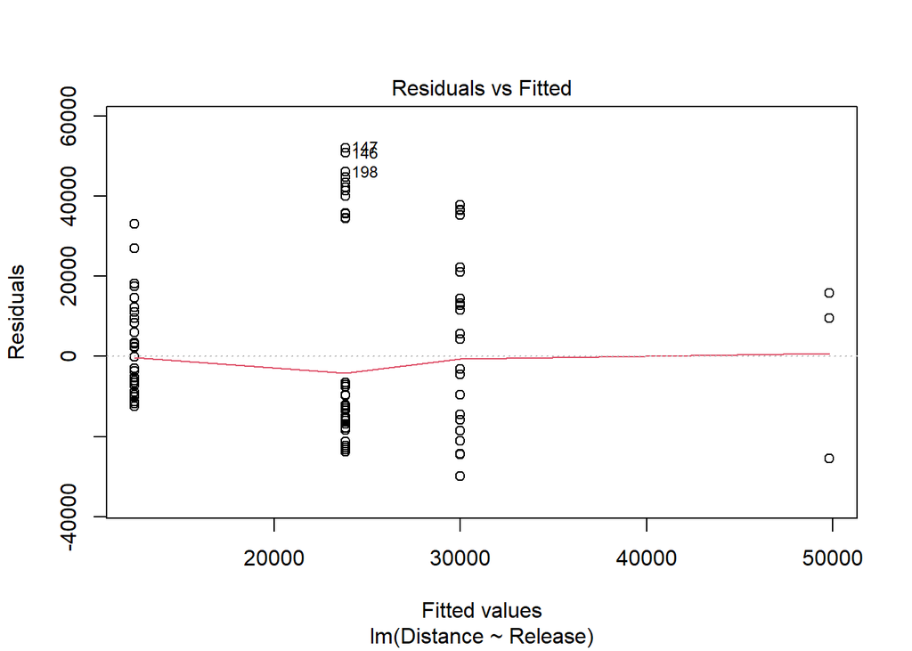

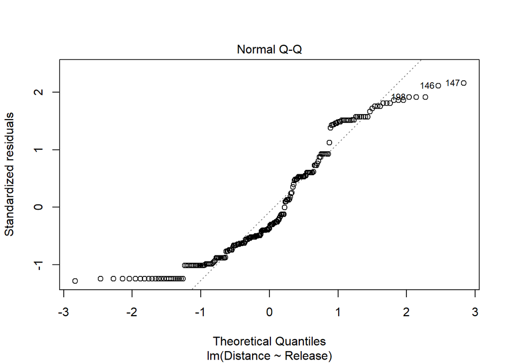

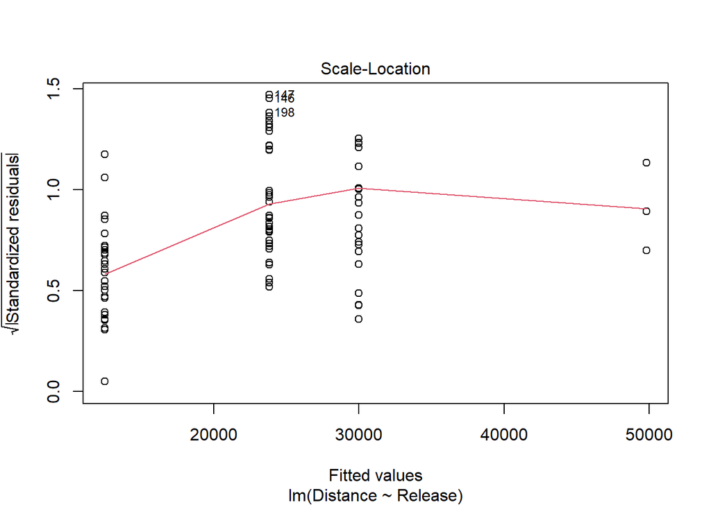

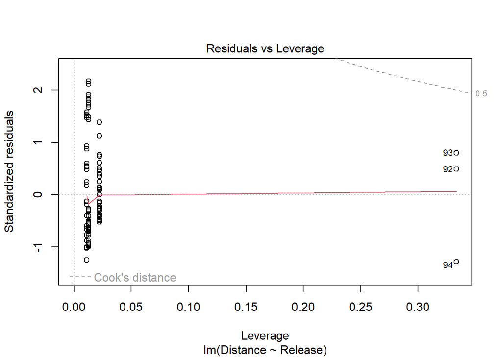

```r
plot(m2)
```

```r
#QQ plot is a bit of a mess I tried log-transforming and sqrt transforming and its still a mess.

emmeans(m2, pairwise ~ Release)
```

```
## $emmeans
##  Release        emmean    SE  df lower.CL upper.CL
##  DWSC Hard       23817  2744 213    18408    29225
##  DWSC Soft       12485  3613 213     5364    19606
##  Rio Vista Hard  29974  2540 213    24967    34982
##  Trailer         49820 13992 213    22241    77400
##
## Confidence level used: 0.95
##
## $contrasts
##  contrast                   estimate    SE  df t.ratio p.value
##  DWSC Hard - DWSC Soft         11332  4537 213   2.498  0.0631
##  DWSC Hard - Rio Vista Hard    -6158  3739 213  -1.647  0.3548
##  DWSC Hard - Trailer          -26004 14258 213  -1.824  0.2650
##  DWSC Soft - Rio Vista Hard   -17490  4416 213  -3.960  0.0006
##  DWSC Soft - Trailer          -37335 14450 213  -2.584  0.0507
##  Rio Vista Hard - Trailer     -19846 14220 213  -1.396  0.5035
##
## P value adjustment: tukey method for comparing a family of 4 estimates
```

```
## I bet you wanted to call this with just object[[1]] - use '[[]]' or which' if I'm wrong.
## See '? emm_list' for more information
```

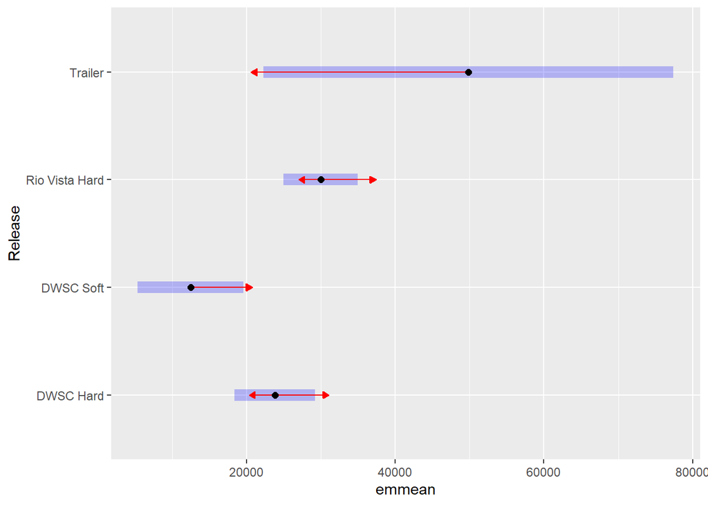

```r
plot(emmeans(m2, pairwise ~ Release), comparisons = T)
```

So DWSC soft were closer together than rio vista hard, but no difference between DWSC hard and DWSC soft

I could also do this by release rather than release type

```r
smeltIDS = select(recaps2, fishID, ReleaseEvent)

nndist2 = left_join(nndist, smeltIDS, by = c("Fish1" = "fishID"))

m3 = lm(Distance ~ ReleaseEvent, data = nndist2)
summary(m3)
```

```
##
## Call:
## lm(formula = Distance ~ ReleaseEvent, data = nndist2)
##
## Residuals:
##    Min     1Q Median     3Q    Max
## -30484 -21235  -8830  17485  52057
##
## Coefficients:
##                 Estimate Std. Error t value Pr(>|t|)
## (Intercept)     23863.32    9170.78   2.602  0.00992 **
## ReleaseEvent2a   6620.42    9545.25   0.694  0.48870
## ReleaseEvent2b  25956.78   16743.48   1.550  0.12257
## ReleaseEvent3a    -46.71    9573.45  -0.005  0.99611
## ReleaseEvent3b -11378.57    9858.29  -1.154  0.24971
## ---
## Signif. codes:  0 '***' 0.001 '**' 0.01 '*' 0.05 '.' 0.1 ' ' 1
##
## Residual standard error: 24260 on 212 degrees of freedom
## Multiple R-squared:  0.08413,    Adjusted R-squared:  0.06685
## F-statistic: 4.869 on 4 and 212 DF,  p-value: 0.0008928
```

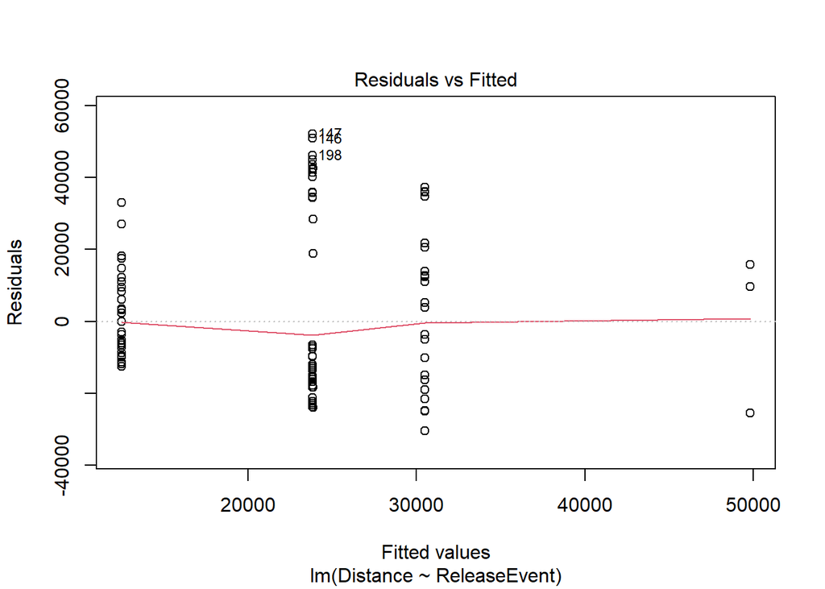

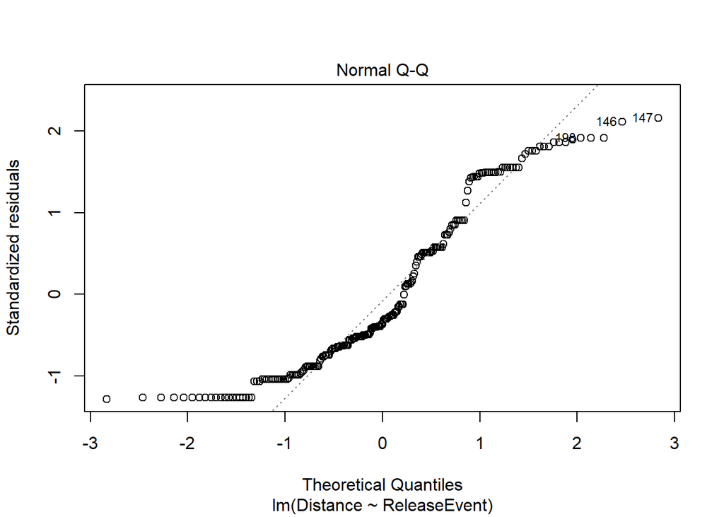

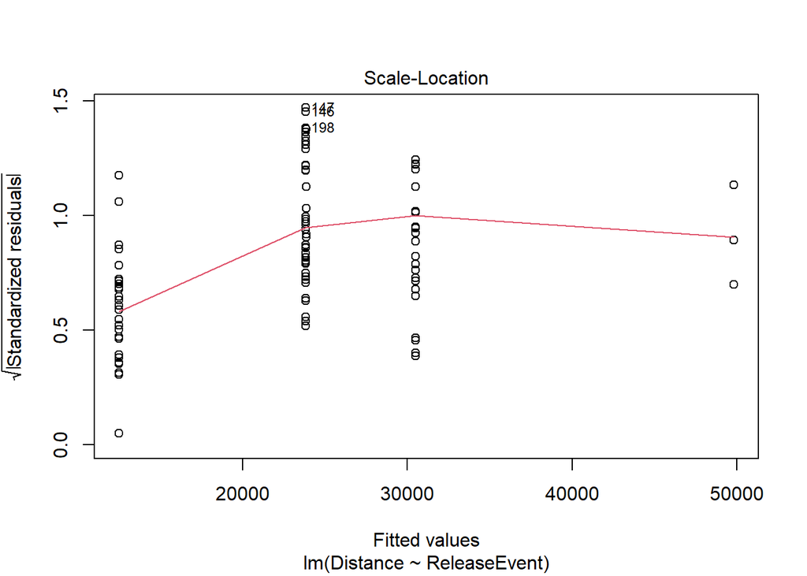

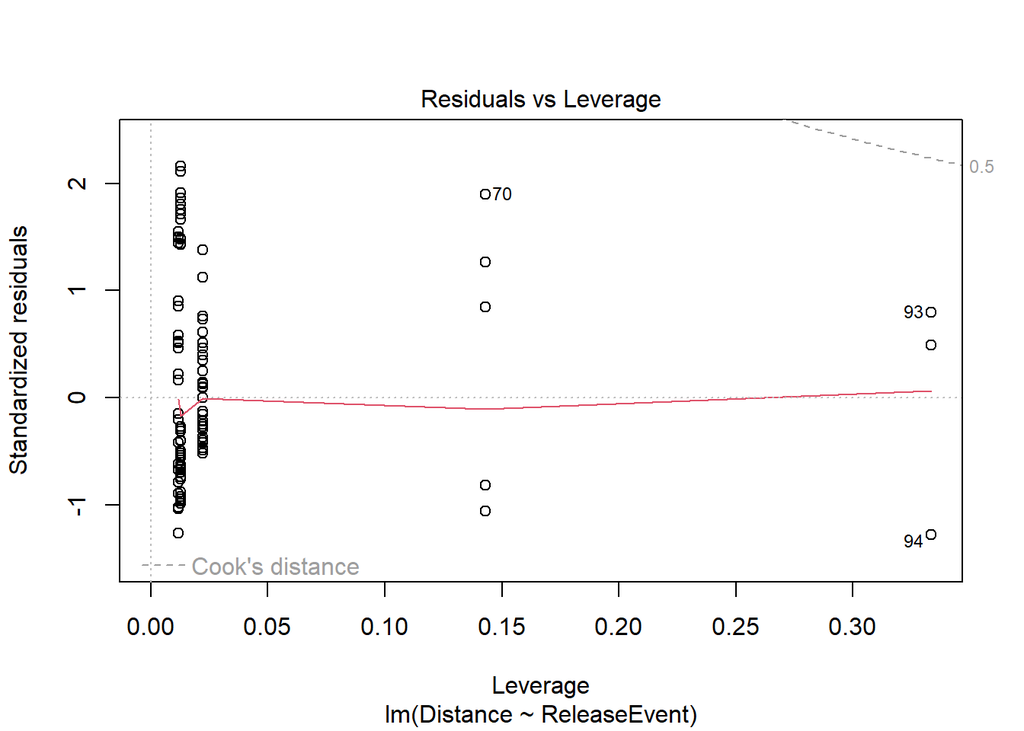

```r
plot(m3)
```

```r
#QQ plot is a bit of a mess I tried log-transforming and sqrt transforming and its still a mess.

emmeans(m3, pairwise ~ ReleaseEvent)
```

```
## $emmeans
##  ReleaseEvent emmean    SE  df lower.CL upper.CL
##  1b            23863  9171 212     5786    41941
##  2a            30484  2647 212    25265    35702
##  2b            49820 14009 212    22206    77434
##  3a            23817  2747 212    18401    29232
##  3b            12485  3617 212     5355    19615
##
## Confidence level used: 0.95
##
## $contrasts
##  contrast estimate    SE  df t.ratio p.value
##  1b - 2a   -6620.4  9545 212  -0.694  0.9577
##  1b - 2b  -25956.8 16743 212  -1.550  0.5310
##  1b - 3a      46.7  9573 212   0.005  1.0000
##  1b - 3b   11378.6  9858 212   1.154  0.7773
##  2a - 2b  -19336.4 14257 212  -1.356  0.6562
##  2a - 3a    6667.1  3815 212   1.747  0.4073
##  2a - 3b   17999.0  4482 212   4.016  0.0008
##  2b - 3a   26003.5 14275 212   1.822  0.3639
##  2b - 3b   37335.3 14468 212   2.581  0.0776
##  3a - 3b   11331.9  4542 212   2.495  0.0956
##
## P value adjustment: tukey method for comparing a family of 5 estimates
```

```
## I bet you wanted to call this with just object[[1]] - use '[[]]' or which' if I'm wrong.
## See '? emm_list' for more information
```

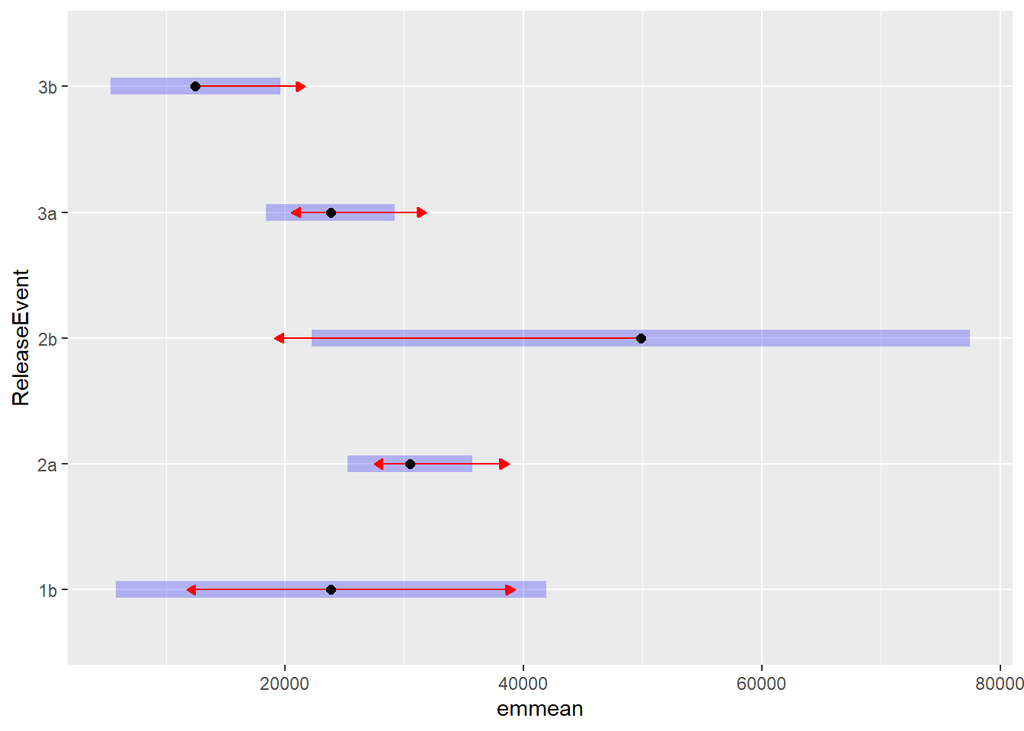

```r
plot(emmeans(m3, pairwise ~ ReleaseEvent), comparisons = T)
```